# STAT545 HW4

Yi Yang

10/3/2018

## 1. Problem 1: Exponential family distributions

1. Consider a random varibale $x$ that can take $D$ values and that is distributed according to the discrete distribution with parameters $\overrightarrow{\pi}$. We will wirte this as $p(x|\overrightarrow{\pi})$, with $p(x = c|\overrightarrow{\pi}) = \pi_c$ for $c \in \{1,\dots,D\}$.
1. Write $p(x|\overrightarrow{\pi})$ as an exponential family distribution and give the natural parameters $\overrightarrow{\eta}$ as a function of $\pi$ (note this means you can also write $\pi$ as a function of $\eta$ though you don’t have to). Also write a minimal feature vector $\phi$ (note $\pi_D = 1 - \sum_{i=1}^{D-1} \pi_i$).
2. Write $E[\phi(x)]$, the expectation of the feature vector $\phi$ as a function of the natural parameters $\overrightarrow{\eta}$. Recall that given some data $X = (x_1,\dots,x_N)$, maximum likelihood estimation (MLE) of $\eta$ (and thus $\pi$) is moment matching (i.e. calculating the empirical average of $\pi$ and setting $\eta$ so that the population average and the empirical average match).

**Solution:**

1. For this discrete distribution, the exponential form is given as follows
1. $$\begin{aligned}
   p(x|\overrightarrow{\pi}) & = \prod_{k=1}^{D} \pi_k^{\delta(x=k)} \\
   & = \exp(\sum_{k=1}^{D} \delta(x = k)\cdot \log(\pi_k))
   \end{aligned}$$

The feature vector is given by $\phi(x) = [\delta(x=1), \delta(x=2),\cdots,\delta(x=D)]^\top$. The natural parameter is given by $\eta = [\log(\pi_1), \log(\pi_2), \cdots, \log(\pi_D)]^\top$. The minial exponential form is derived as follows, the minial feature vector is given by $\phi(x) = [\delta(x=1),\delta(x=2),\cdots,\delta(x=D-1)]^\top$.
$$\begin{aligned}
p(x|\overrightarrow{\pi}) & = \exp(\sum_{k=1}^{D} \delta(x = k)\cdot \log(\pi_k)) \\
& = \exp(\sum_{k=1}^{D-1}\delta(x = k)\log(\frac{\pi_k}{\pi_D}) + \sum_{k=1}^{D-1}\delta(x=k)\log(\pi_D) + \delta(x=D)\log(\pi_D)) \\
& = \pi_D\exp(\sum_{k=1}^{D-1}\delta(x=k)\log(\frac{\pi_k}{\pi_D}))
\end{aligned}$$

2. The expectation of the feature vector is given by
   $$\mathop{\mathbb{E}}[\phi(x)] = \begin{bmatrix}
   \mathop{\mathbb{E}}[\delta(x=1)]\\
   \vdots \\
   \mathop{\mathbb{E}}[\delta(x=D)]
   \end{bmatrix} = \begin{bmatrix}
   \pi_1 \\
   \vdots \\
   \pi_D
   \end{bmatrix} = \exp(\eta)$$
2. Let $x$ be Poisson distributed with mean $\lambda$. Repeat parts (a), (b).
3. Let $x$ be a 1-dimensional Gaussian with mean $\mu$ and variance $\sigma^2$. Repeat parts (a), (b) (Note: both $\mu$ and $\sigma^2$ are parameters).
4. Let $x$ follow a geometric distribution with success probability $p$: ($Pr(X = k) = (1 - p)^kp$ for $k = 0,1,2,\dots$). Repeat parts (a), (b).

## 2. Problem 2: EM for mixture of Bernoulli vectors

1. We looked at the MNIST dataset last assignment. Write code to create a new dataset of only twos and threes using the information in $\mathrm{labels}$. Each pixel can take values from 1 to 256: now threshold the images to be binary (0 or 1). Use a threshold between 1 to 5 (whatever you think is best). Do not use a for loop.

We will model these binary images as a mixture of $K$ Bernoulli vectors. Thus, we have $K$ clusters, each of which is parametrized by a 784-dimensional vector with each component lying between 0 and 1. Call the $k$th cluster parameter $\mu^k$, with $\mu^k \in [0,1]^{784}$. The probability over clusters is a $k$-component probability vector $\pi$. Thus, to generate an observation, we first sample a cluster $c$ from $\pi$, and then generate a random binary image $x$ by setting the $i$th pixel to 1 with probability $\mu_i^k$ for $i$ from 1 to 784.

2. Given $N$ observations $X = (x_1, \dots , x_N )$ and their cluster assignments $C = (c_1, \dots , c_N )$, write down the log joint-probability $\log p(X,C|\pi,\overrightarrow{\mu})$.
3. If we observed both $X$ and $C$, what are the maximum likelihood estimates of $\pi$ and the $\mu^k$s?
4. Explain why $p(C|X,\pi,\overrightarrow{\mu}) = \prod_{i=1}^N p(c_i|x_i,\pi,\overrightarrow{\mu})$.. Write down $p(c_i|x_i,\pi,\overrightarrow{\mu})$. This is the $q$ of the EM algorithm.
5. Write down the variational lower bound $\mathcal{F}(q,\pi,\overrightarrow{\mu})$ for the EM algorithm. Use the first expression in the slides involving the entropy $H(q)$.
6. For a given $q$, what are the $\pi$ and $\overrightarrow{\mu}$ that maximize this? These expressions should be a simple relaxation of part (3).
7. Write an EM algorithm that maximizes $\mathcal{F}$ by alternately maximizing w.r.t. $q$ (step 4) and $(\pi,\overrightarrow{\mu})$ (step 6). Although the algorithm doesn’t require you to evaluate $\mathcal{F}$, your code should do this after each update. This is a useful diagnostic for debugging since $\mathcal{F}$ should never decrease. Your stopping criteria should be when the value of $\mathcal{F}$ stabilizes.
8. Run the EM algorithm on the binary digits data set for $K = 2$ and $3$. Plot the cluster parameters using $\mathrm{show\_digit}$. Also plot the trace of the evolution of $\mathcal{F}$. Write down the final value of $\pi$ and $\mathcal{F}$. What are the units of the latter?
9. The entropy of a distribution is a measure of how ‘random’ it is. For $K = 2$, calculate the entropy of the final $q(c_i|x_i,\overrightarrow{\mu},\pi)$ of each digit, and plot the digit with the largest entropy. This is the digit with largest ambiguity about its correct cluster.

**Solution:**

```r
# Credit to https://gist.github.com/brendano/39760
# Load the MNIST digit recognition dataset into R

load_image_file <- function(filename) {
  ret = list()
  f = file(filename,'rb')
  readBin(f,'integer',n=1,size=4,endian='big')
  ret$n = readBin(f,'integer',n=1,size=4,endian='big')
  nrow = readBin(f,'integer',n=1,size=4,endian='big')
  ncol = readBin(f,'integer',n=1,size=4,endian='big')
  x = readBin(f,'integer',n=ret$n*nrow*ncol,size=1,signed=F)
  ret$x = matrix(x, ncol=nrow*ncol, byrow=T)
  close(f)
  ret
}
load_label_file <- function(filename) {
  f = file(filename,'rb')
  readBin(f,'integer',n=1,size=4,endian='big')
  n = readBin(f,'integer',n=1,size=4,endian='big')
  y = readBin(f,'integer',n=n,size=1,signed=F)
  close(f)
  y
}

show_digit <- function(arr784, col=gray(12:1/12), ...) {
  image(matrix(arr784, nrow=28)[,28:1], col=col,axes=F, ...)
}

# load the first 1000 digits and their labels
digits.list <- load_image_file('../HW3/data/train-images-idx3-ubyte')
digits <- digits.list$x[1:1000,]
#digits <- digits / 255.0 # normalize pixels
digits <- ifelse(digits<4, 0, 1)
labels <- load_label_file('../HW3/data/train-labels-idx1-ubyte')
dim(digits)
```

```
## [1] 1000  784
```

[figure not shown]

```r
show_digit(digits[1,])
```

2. The joint probability is given by
   $$p(X,C|\pi,\overrightarrow{\mu}) = \prod_{n=1}^N\prod_{k=1}^K\left[\pi_k\prod_{d=1}^D \left(\mu^k_d\right)^{x_{nd}}\left(1 - \mu^k_d\right)^{1-x_{nd}}\right]^{\delta(c_n = k)}$$
   $$\log p(X,C|\pi,\overrightarrow{\mu}) = \sum_{n=1}^N\sum_{k=1}^K\delta(c_n = k)\left\{\log\pi_k + \sum_{d=1}^D\left[x_{nd}\log\mu^k_d + (1 - x_{nd})\log(1-\mu^k_d)\right]\right\}$$
3. Consider this constrained optimization problem, introduce the Lagrange multiplier $\lambda$, we have:
   $$\arg \max \log p(X,C|\pi,\overrightarrow{\mu}) + \lambda(\sum_{k=1}^K \pi_k - 1)$$
   Taking derivative to $\pi_k$, we have
   $$\frac{\sum_{n=1}^N \delta(c_n = k)}{\pi_k} + \lambda = 0$$
   Multiply both sides by $\pi_k$ and sum over $k = 1,\dots, K$, we have
   $$\lambda = -\sum_{k=1}^K\sum_{n=1}^N \delta(c_n = k) = -N$$
   Therefore, we have
   $$\pi_k = \frac{\sum_{n=1}^N \delta(c_n = k)}{N}$$
   Taking derivative to $\mu^k_d$, we have
   $$\sum_{n=1}^N \delta(c_n = k)\left[\frac{x_{nd}}{\mu^k_d} - \frac{1-x_{nd}}{1 - \mu^k_d}\right] = 0$$
   Therefore, we have
   $$\mu^k_d = \frac{\sum_{n=1}^N x_{nd}\delta(c_n=k)}{\sum_{n=1}^N\delta(c_n=k)}$$
4. Each observation is independent to each other. The joint posterior probability is the product of the marginal posterior probability.
   $$q_{n,k} = p(c_n = k|x_n, \pi,\overrightarrow{\mu}) = \frac{\pi_kp(x_n|\mu^k)}{\sum_{j=1}^K \pi_jp(x_n|\mu^j)}$$
5. The variational lower bound is given by
   $$\begin{aligned}
   F(q,\pi,\overrightarrow{\mu}) & = \mathop{\mathbb{E}_q}[\log p(X,C|\pi,\overrightarrow{\mu})] + H(q)\\
   & = \sum_{n=1}^N\sum_{k=1}^K q_{n,k}\left\{\log\pi_k + \sum_{d=1}^D\left[x_{nd}\log\mu^k_d + (1 - x_{nd})\log(1-\mu^k_d)\right]\right\} - \sum_{n=1}^N\sum_{k=1}^K q_{n,k}\log q_{n,k}
   \end{aligned}$$
6. Analagous to part 3, the estimated parameters should be, given $N_k = \sum_{n=1}^N q_{n,k}$
   $$\pi_k = \frac{N_k}{N}$$
   $$\mu^k_d = \frac{\sum_{n=1}^N x_{nd}\cdot q_{n,k}}{N_k}$$
7. The algorithm is implemented as follows

```r
em <- function(Obs, K){
  # slog ignore zero logrithm
  slog <- function(val){
    pos <- val > 0
    val[pos] <- log(val[pos])
    return(val)
  }
  set.seed(12)
  # obtain sizes
  N <- nrow(Obs)
  D <- ncol(Obs)
  Pi <- runif(K,0,1)
  Pi <- Pi / sum(Pi)
  mu <- matrix(runif(D*K,0,1),nrow = D)
  q <- matrix(rep(0,N*K), nrow = N)
  temp <- rep(0,K)

  Tol <- 1e-2
  Change <- Tol + 1
  maxIter <- 100
  it <- 0
  Fvalue <- c()
  while (it <= maxIter && Tol <= Change) {
    # E step
    for (n in seq(1,N)){
      x <- Obs[n,]
      for (k in seq(1,K)){
        temp[k] = slog(Pi[k]) + sum(x*slog(mu[,k])) + sum((1 - x)*slog(1 - mu[,k]))
      }
      temp <- temp - max(temp)
      q[n,] <- exp(temp)/sum(exp(temp))
    }

    # M step
    Nk <- colSums(q)
    Pi <- Nk/N

    mu_update <- matrix(rep(0,D*K), nrow = D)
    for (kk in seq(1,K)){
      mu_update[,kk] <- colSums(q[,kk]*Obs)/Nk[kk]
    }
    Change <- max(abs(mu - mu_update))
    mu <- mu_update
    it <- it + 1

    # update F value
    fvalue <- 0
    for (n in seq(1,N)){
      x <- Obs[n,]
      for (k in seq(1,K)){
        temp[k] = slog(Pi[k]) + sum(x*slog(mu[,k])) + sum((1 - x)*slog(1 - mu[,k]))
        fvalue <- fvalue + q[n,k]*temp[k] - q[n,k]*slog(q[n,k])
      }
    }
    Fvalue <- c(Fvalue, fvalue)
  }

  return(list(Pi=Pi,mu=mu,q=q,Fvalue=Fvalue,it=it))
}
```

```r
#K = 2
examp <- em(digits,2)
for (id in seq(1,ncol(examp$mu))){
  show_digit(examp$mu[,id])
}
```

[figure not shown]

[figure not shown]

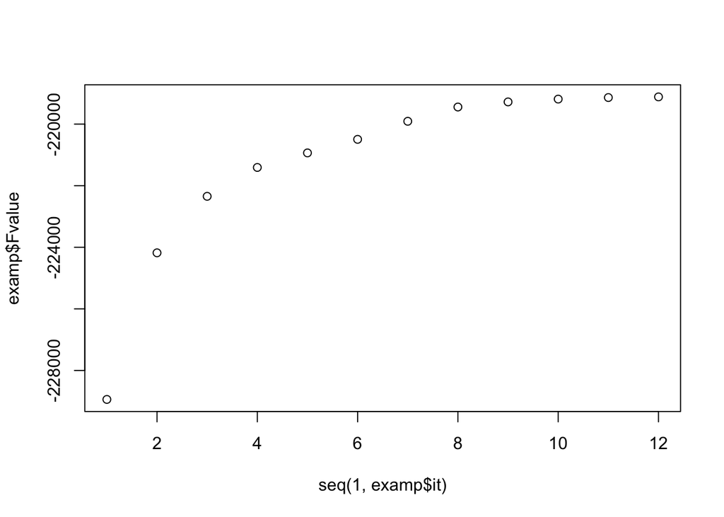

```r
plot(seq(1,examp$it),examp$Fvalue)
```

```r
cat(paste('Final value of pi and F:\n'))
```

```
## Final value of pi and F:
```

```r
print(examp$Pi)
```

```
## [1] 0.5758176 0.4241824
```

```r
print(examp$Fvalue[examp$it])
```

```
## [1] -219116.1
```

```r
#K = 3
examp <- em(digits,3)
for (id in seq(1,ncol(examp$mu))){
  show_digit(examp$mu[,id])
}
```

[figure not shown]

[figure not shown]

[figure not shown]

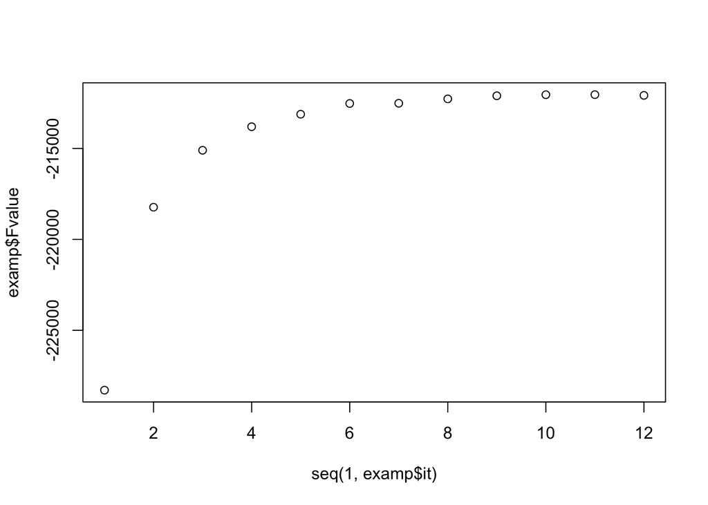

```r
plot(seq(1,examp$it),examp$Fvalue)
```

```r
cat(paste('Final value of pi and F:\n'))
```

```
## Final value of pi and F:
```

```r
print(examp$Pi)
```

```
## [1] 0.4569846 0.3563021 0.1867133
```

```r
print(examp$Fvalue[examp$it])
```

```
## [1] -212080.2
```

```r
examp <- em(digits,2)
Q <- examp$q
dim(Q)
```

```
## [1] 1000    2
```

[figure not shown]

```r
# slog ignore zero logrithm
slog <- function(val){
  pos <- val > 0
  val[pos] <- log(val[pos])
  return(val)
}
Entropy <- apply(Q,1,function(x) sum(-x*slog(x)))
show_digit(digits[which(Entropy == max(Entropy)),])
```